# Descriptive statistics

Anuschka Peelen

2023-05-18

In this script, I write the code to make some plots and tables that I use to in the data and analysis section. You will find the code for the plot with datasets per year, the Table with individual regression analysis for one variable of ISSP and the Table with all the pooled effects.

```r
library(dplyr)
library(here)
library(ggplot2)
library(kableExtra)
library(tidyverse)
library(writexl)
library(readxl)
library(gamlss)
here()
here::i_am("scripts/descriptive_stats/descriptives.Rmd")
```

## Ggplot that shows the years that each dataset covers

```r
datayear <- read_excel("/Users/anuschka/Documents/climatechange/climatechange/data/descriptives/dataset_year.xlsx")
```

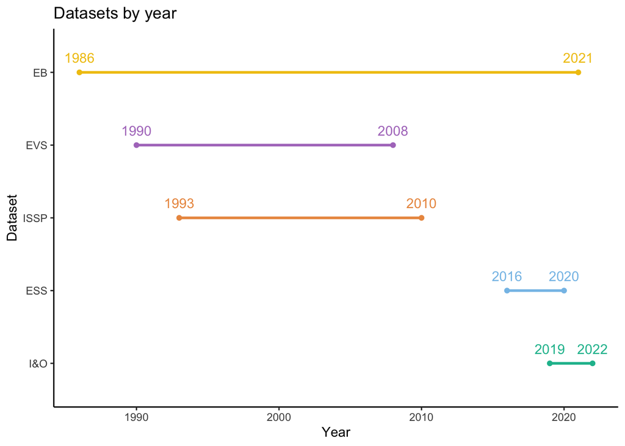

```r
color_scale <- c ("#1ABC9C", "#85C1E9" , "#EB984E", "#AF7AC5" , "#F1C40F")
datayear$dataset <- factor(datayear$dataset, levels = c("I&O", "ESS", "ISSP", "EVS", "EB"))

first_last_year <- datayear %>%
  group_by(dataset) %>%
  summarize(first_year = min(year),
            last_year = max(year))

yearplot <- ggplot(data = datayear, aes(x = year, y = dataset, color = dataset)) +
  geom_line(size = 1) +
  scale_color_manual(values = color_scale) +
  labs(title = "Datasets by year",
       x = "Year",
       y = "Dataset") +
  geom_point(data = first_last_year, x = first_last_year$first_year) +
  geom_point(data = first_last_year, x = first_last_year$last_year) +
  geom_text(data = first_last_year, x = first_last_year$first_year, label = first_last_year$first_year, vjust = -1) +
  geom_text(data = first_last_year, x = first_last_year$last_year, label = first_last_year$last_year, vjust = -1) +
  theme_classic() +
  guides(color = FALSE)

yearplot
```

```r
#ggsave("yearplot.png", width = 7, height = 5, path = "/Users/anuschka/Documents/climatechange/climatechange/output/yearplot.png")
```

## Table of the GAMLSS regression output

```r
# Run this piece of code so that in the Table beneath it will not show NAs
options(knitr.kable.NA = '')
```

```r
# Illustrate the gamlss regressions by showing one from ISSP with kable extra
load(here("./data/final_data/regression_outputs", "issp_list_empty_w.Rdata"))
load(here("./data/final_data/regression_outputs", "issp_list_preds_w_new.Rdata"))
load(here("./data/final_data/regression_outputs", "issp_list_interactions_w_new.Rdata"))

# Use first variable, which is "worry"
model_time_only <- summary(issp_list_empty[[1]])
model_time_only_df <- as.data.frame(model_time_only)
model_time_only_df$mu_sigma <- c("Mu", "", "Sigma", "")
model_time_only_df$variables <- c("Intercept", "Time", "Intercept", "Time")
model_time_only_df <- model_time_only_df %>% dplyr:: select(mu_sigma, variables, everything())
rownames(model_time_only_df) <- NULL

model_indep_df <- as.data.frame(summary(issp_list_preds[[1]]))
model_indep_df$mu_sigma <- c("Mu", "", "", "", "", "","Sigma", "", "", "", "", "")
model_indep_df$variables <- c("Intercept", "Time", "Gender",  "Isced intermediate (ref=basic)", "Isced advanced (ref=basic)", "Age", "Intercept", "Time", "Gender",  "Isced intermediate (ref=basic)", "Isced advanced (ref=basic)", "Age")
model_indep_df <- model_indep_df %>% dplyr::select(mu_sigma, variables, everything())
rownames(model_indep_df) <- NULL

model_interact_df <- as.data.frame(summary(issp_list_interactions[[1]]))
model_interact_df$mu_sigma <- c("Mu", "", "", "", "", "", "", "", "", "", "Sigma", "", "", "", "", "", "", "", "", "")
model_interact_df$variables <- c("Intercept", "Time", "Gender",  "Isced intermediate (ref=basic)", "Isced advanced (ref=basic)", "Age", "Age x time", "Gender x time", "Isced intermediate x time", "Isced advanced x time", "Intercept", "Time", "Gender",  "Isced intermediate (ref=basic)", "Isced advanced (ref=basic)", "Age", "Age x time", "Gender x time", "Isced intermediate x time", "Isced advanced x time")
model_interact_df <- model_interact_df %>% dplyr::select(mu_sigma, variables, everything())
rownames(model_interact_df) <- NULL

# Difficult to columnbind them, because they're of different lengths (logically), so use a function
df_list <- list(model_time_only_df, model_indep_df, model_interact_df)

bind_cols_fill <- function(df_list) {

  max_rows <- map_int(df_list, nrow) %>% max()

  map(df_list, function(df) {
    if(nrow(df) == max_rows) return(df)
    first <- names(df)[1] %>% sym()
    df %>% add_row(!!first := rep(NA, max_rows - nrow(df)))
  }) %>% bind_cols()
}

model_total <- bind_cols_fill(df_list)

model_total[is.na(model_total)] <- ""

# The dataframe is binded, the order is not totally how i want it. The data are now all centered at the top, but for the
# previous models, I need the data to be centered around the mu/intercept and sigma/intercept (with a lot of blank spaces). # Furthermore, some variables have a name that have special signs in them, which causes R not to recognize them. To make it #easy, I quickly fix these things in Excel. I don't make any changes to the data
write_xlsx(model_total, here("./data/descriptives/", "kable_model_total_gamlss.xlsx" ))
```

```r
model_new <- read_excel(here("./data/descriptives/", "kable_model_total_gamlss.xlsx" ))

# I Want to round the numeric variables to 3 decimals
model_new <- mutate_at(model_new, vars(-mu_sigma, -variables), as.numeric)
numeric_cols <- sapply(model_new, is.numeric)
model_new[, numeric_cols] <- round(model_new[, numeric_cols], digits = 3)

# There are some annoying variable names that R can't recognize because it has spacing, so rename the columns
colnames(model_new) <- (c("mu_sigma", "Variables", "est_time", "std_err_time", "p_time", "est_indep", "std_err_indep", "p_indep", "est_inter", "std_error_inter", "p_inter", "p_text_time_only", "p_text_indep", "p_text_inter"))

# Create a new variable to use stars instead of the full p-values in the table
model_new$p_text_time_only <- case_when(
  model_new$p_time >= 0.05 ~ "",
model_new$p_time < 0.001 ~ "***",
model_new$p_time < 0.01 ~ "**",
model_new$p_time < 0.05 ~ "*"
)

model_new$p_text_indep <- case_when(
  model_new$p_indep >= 0.05 ~ "",
model_new$p_indep < 0.001 ~ "***",
model_new$p_indep < 0.01 ~ "**",
model_new$p_indep < 0.05 ~ "*"
)

model_new$p_text_inter <- case_when(
  model_new$p_inter >= 0.05 ~ "",
model_new$p_inter < 0.001 ~ "***",
model_new$p_inter < 0.01 ~ "**",
model_new$p_inter < 0.05 ~ "*"
)

# Now only select the variables that I want to show in the table
model_new <- dplyr::select(model_new, mu_sigma, Variables, est_time, std_err_time, p_text_time_only, est_indep, std_err_indep, p_text_indep, est_inter, std_error_inter, p_text_inter)

# Make and save the table
kable(model_new, digits = 3, caption = "Table 2. GAMLSS model on worry ISSP (1993 - 2010)",
      col.names = c( "", "Variables", "Estimate", "Std. Error", "", "Estimate", "Std. Error", "", "Estimate", "Std. Error", ""), align = "l") %>%
  kable_classic_2(html_font = "Times", fixed_thead = T, full_width = F) %>%
  add_header_above(c(" " = 2, "Time-only model" = 3, "Indepent var model" = 3, "Interaction model" = 3), align = "l") %>%
   footnote(
    general_title = "Note.",
    general = "*** = p < 0.001, ** = p < 0.01, * = p < 0.05",
    threeparttable = TRUE,
    footnote_as_chunk = TRUE
    )
```

Table 2. GAMLSS model on worry ISSP (1993 - 2010)

Time-only model

Indepent var model

Interaction model

Variables

Estimate

Std. Error

Estimate

Std. Error

Estimate

Std. Error

Mu

Intercept

3.358

0.029

***

3.453

0.086

***

3.602

0.120

***

Time

-0.005

0.003

-0.011

0.003

***

-0.045

0.015

Gender

0.183

0.038

***

0.173

0.055

Isced intermediate (ref=basic)

0.468

0.040

***

0.397

0.055

***

Isced advanced (ref=basic)

0.002

0.031

0.004

0.045

Age

-0.008

0.001

***

-0.011

0.002

***

Age x time

0.000

0.000

Gender x time

0.002

0.005

Isced intermediate x time

0.009

0.008

Isced advanced x time

0.016

0.008

Sigma

Intercept

1.065

0.020

***

1.109

0.061

***

1.038

0.085

***

Time

0.001

0.002

0.003

0.002

0.008

0.011

Gender

-0.087

0.027

-0.070

0.039

Isced intermediate (ref=basic)

-0.093

0.028

-0.122

0.039

Isced advanced (ref=basic)

-0.028

0.022

-0.023

0.032

Age

0.000

0.001

0.002

0.001

Age x time

0.000

0.000

Gender x time

-0.002

0.004

Isced intermediate x time

0.006

0.006

Isced advanced x time

0.006

0.006

Note. *** = p < 0.001, ** = p < 0.01, * = p < 0.05

```r
#%>%
    #save_kable("/Users/anuschka/Documents/climatechange/climatechange/output/gamlss_table.pdf")
```

## Table all pooled effects

```r
rm(list=ls())
# I want to repeat the above Table, but instead of regressions I now want to put all the pooled effects in there
# Starting with the time only model
# You may notice that I use the rma function and metagen. The estimate TE.random of metagen (pooled effect) is the same as the beta in the rma model
set.seed(1) #(as I am performing analyses with a random aspect)

load(here("./data/meta_analysis", "total_reg_results_gam_w_new.RData"))

# Extract the pooled effects, first mean attitudes
model_step_1_att <- rma(yi = mu_time,
              sei = mu_time_sd,
              data = total_reg_results,
              method = "REML",
              test = "knha")

one <- summary(model_step_1_att)
one_df <- data.frame(matrix(ncol = 5, nrow = 1))
colnames(one_df) <- c("mu_sigma", "Variable", "Estimate", "SE", "p")

one_df$mu_sigma <- c("Mean attitudes")
one_df$Variable <- "Time"
one_df$Estimate <- as.numeric(one$b)
one_df$SE <- one$se
one_df$p <- one$pval

# And now variance
model_step_1_var <- rma(yi = sig_time,
              sei = sig_time_sd,
              data = total_reg_results,
              method = "REML",
              test = "knha")

two <- summary(model_step_1_var)
two_df <- data.frame(matrix(ncol = 5, nrow = 1))
colnames(two_df) <- c("mu_sigma", "Variable", "Estimate", "SE", "p")

two_df$mu_sigma <- c("Polarization attitudes")
two_df$Variable <- "Time"
two_df$Estimate <- as.numeric(two$b)
two_df$SE <- two$se
two_df$p <- two$pval

# Rowbind them, these are all the pooled effects of the time-only model
empty_df <- rbind(one_df, two_df)

# Now continue with the independent variable model, first the mean attitudes
load(here("./data/meta_analysis", "total_indep_var_results_new.RData"))

m2_att <- rma(yi = mu_time_pred,
              sei = mu_time_sd_pred,
              data = total_reg_results,
              method = "REML",
              test = "knha")

# Gender
gender_gen <- metagen(TE = mu_sex_est,
                 seTE = mu_sex_sd,
                 data = total_indep_var_results,
                 fixed = FALSE,
                 random = TRUE,
                 method.tau = "REML",
                 hakn = TRUE)

# Age
age_gen <- metagen(TE = mu_age_est,
                 seTE = mu_age_sd,
                 data = total_indep_var_results,
                 fixed = FALSE,
                 random = TRUE,
                 method.tau = "REML",
                 hakn = TRUE)

# Educational level. This is now a dummy
edu_med_gen <- metagen(TE = mu_isced_med_est,
                 seTE = mu_isced_med_sd,
                 data = total_indep_var_results,
                 fixed = FALSE,
                 random = TRUE,
                 method.tau = "REML",
                 hakn = TRUE)

edu_high_gen <- metagen(TE = mu_isced_high_est,
                 seTE = mu_isced_high_sd,
                 data = total_indep_var_results,
                 fixed = FALSE,
                 random = TRUE,
                 method.tau = "REML",
                 hakn = TRUE)

# Extract all the data from the models and put them in a dataframe that will later be the input of the kable table
three_df <- data.frame(matrix(ncol = 5, nrow = 5))
colnames(three_df) <- c("mu_sigma_1", "Variable_1", "Estimate_1", "SE_1", "p_1")
three_df$mu_sigma_1 <- c("Mean attitudes", "", "", "", "")
three_df$Variable_1 <- c("Time", "Gender", "Age", "Isced intermediate (ref=basic)", "Isced advanced (ref=basic)")
three_df$Estimate_1 <- c(as.numeric(m2_att$b), gender_gen$TE.random, age_gen$TE.random, edu_med_gen$TE.random, edu_high_gen$TE.random)
three_df$SE_1 <- c(m2_att$se, gender_gen$seTE.random, age_gen$seTE.random, edu_med_gen$seTE.random, edu_high_gen$seTE.random)
three_df$p_1 <- c(m2_att$pval, gender_gen$pval.random, age_gen$pval.random, edu_med_gen$pval.random, edu_high_gen$pval.random)

# The same for variance
m2_var <- rma(yi = sig_time_pred,
              sei = sig_time_sd_pred,
              data = total_reg_results,
              method = "REML",
              test = "knha")

# Gender
gender_var_gen <- metagen(TE = sig_sex_est,
                 seTE = sig_sex_sd,
                 data = total_indep_var_results,
                 fixed = FALSE,
                 random = TRUE,
                 method.tau = "REML",
                 hakn = TRUE)

# Age
age_var_gen <- metagen(TE = sig_age_est,
                 seTE = sig_age_sd,
                 data = total_indep_var_results,
                 fixed = FALSE,
                 random = TRUE,
                 method.tau = "REML",
                 hakn = TRUE)

# Education
edu_var_med_gen <- metagen(TE = sig_isced_med_est,
                 seTE = sig_isced_med_sd,
                 data = total_indep_var_results,
                 fixed = FALSE,
                 random = TRUE,
                 method.tau = "REML",
                 hakn = TRUE)

edu_var_high_gen <- metagen(TE = sig_isced_high_est,
                 seTE = sig_isced_high_sd,
                 data = total_indep_var_results,
                 fixed = FALSE,
                 random = TRUE,
                 method.tau = "REML",
                 hakn = TRUE)

four_df <- data.frame(matrix(ncol = 5, nrow = 5))
colnames(four_df) <- c("mu_sigma_1", "Variable_1", "Estimate_1", "SE_1", "p_1")
four_df$mu_sigma_1 <- c("Polarization attitudes", "", "", "", "")
four_df$Variable_1 <- c("Time", "Gender", "Age", "Isced intermediate (ref=basic)", "Isced advanced (ref=basic)")
four_df$Estimate_1 <- c(as.numeric(m2_var$b), gender_var_gen$TE.random, age_var_gen$TE.random, edu_var_med_gen$TE.random, edu_var_high_gen$TE.random)
four_df$SE_1 <- c(m2_att$se, gender_var_gen$seTE.random, age_var_gen$seTE.random, edu_var_med_gen$seTE.random, edu_var_high_gen$seTE.random)
four_df$p_1 <- c(m2_att$pval, gender_var_gen$pval.random, age_var_gen$pval.random, edu_var_med_gen$pval.random, edu_var_high_gen$pval.random)


# Bind rows of these two, these are all the pooled effects of the independent variables model
indep_df <- rbind(three_df, four_df)

#Now i want the interaction model as well
load("/Users/anuschka/Documents/climatechange/climatechange/data/meta_analysis/total_inter_results_new.RData")
```

```r
# First mean attitudes
m3_att <- rma(yi = mu_time_int,
              sei = mu_time_sd_int,
              data = total_reg_results,
              method = "REML",
              test = "knha")

# Gender
gender_gen_int <- metagen(TE = mu_sex_est,
                 seTE = mu_sex_sd,
                 data = total_inter_results,
                 fixed = FALSE,
                 random = TRUE,
                 method.tau = "REML",
                 hakn = TRUE)

# Age
age_gen_int <- metagen(TE = mu_age_est,
                 seTE = mu_age_sd,
                 data = total_inter_results,
                 fixed = FALSE,
                 random = TRUE,
                 method.tau = "REML",
                 hakn = TRUE)

# Educational level
edu_med_gen_int <- metagen(TE = mu_isced_med_est,
                 seTE = mu_isced_med_sd,
                 data = total_inter_results,
                 fixed = FALSE,
                 random = TRUE,
                 method.tau = "REML",
                 hakn = TRUE)

edu_high_gen_int <- metagen(TE = mu_isced_high_est,
                 seTE = mu_isced_high_sd,
                 data = total_inter_results,
                 fixed = FALSE,
                 random = TRUE,
                 method.tau = "REML",
                 hakn = TRUE)

# And the interaction effects
# Gender
gender_int_eff <- metagen(TE = mu_sex_est_inter,
                 seTE = mu_sex_sd_inter,
                 data = total_inter_results,
                 fixed = FALSE,
                 random = TRUE,
                 method.tau = "REML",
                 hakn = TRUE)

# Age
age_int_eff <- metagen(TE = mu_age_est_inter,
                 seTE = mu_age_sd_inter,
                 data = total_inter_results,
                 fixed = FALSE,
                 random = TRUE,
                 method.tau = "REML",
                 hakn = TRUE)

# Educational level
edu_med_int_eff <- metagen(TE = mu_isced_med_est_inter,
                 seTE = mu_isced_med_sd_inter,
                 data = total_inter_results,
                 fixed = FALSE,
                 random = TRUE,
                 method.tau = "REML",
                 hakn = TRUE)

edu_high_int_eff <- metagen(TE = mu_isced_high_est_inter,
                 seTE = mu_isced_high_sd_inter,
                 data = total_inter_results,
                 fixed = FALSE,
                 random = TRUE,
                 method.tau = "REML",
                 hakn = TRUE)

# Now extract the data for a table
five_df <- data.frame(matrix(ncol = 5, nrow = 9))
colnames(five_df) <- c("mu_sigma_2", "Variable_2", "Estimate_2", "SE_2", "p_2")
five_df$mu_sigma_2 <- c("Mean attitudes", "", "", "", "", "", "", "", "")
five_df$Variable_2 <- c("Time", "Gender", "Age", "Isced intermediate (ref=basic)", "Isced advanced (ref=basic)", "Gender x time", "Age x time", "Isced intermediate x time", "Isced advanced x time")
five_df$Estimate_2 <- c(as.numeric(m3_att$b), gender_gen_int$TE.random, age_gen_int$TE.random, edu_med_gen_int$TE.random, edu_high_gen_int$TE.random, gender_int_eff$TE.random, age_int_eff$TE.random, edu_med_int_eff$TE.random, edu_high_int_eff$TE.random)
five_df$SE_2 <- c(m3_att$se, gender_gen_int$seTE.random, age_gen_int$seTE.random, edu_med_gen_int$seTE.random, edu_high_gen_int$seTE.random, gender_int_eff$seTE.random, age_int_eff$seTE.random, edu_med_int_eff$seTE.random, edu_high_int_eff$seTE.random)
five_df$p_2 <- c(m3_att$pval, gender_gen_int$pval.random, age_gen_int$pval.random, edu_med_gen_int$pval.random, edu_high_gen_int$pval.random, gender_int_eff$pval.random, age_int_eff$pval.random, edu_med_int_eff$pval.random, edu_high_int_eff$pval.random)

# Now the same procedure for the variance
m3_var <- rma(yi = sig_time_int,
              sei = sig_time_sd_int,
              data = total_reg_results,
              method = "REML",
              test = "knha")

# Gender
gender_gen_int_var <- metagen(TE = sig_sex_est,
                 seTE = sig_sex_sd,
                 data = total_inter_results,
                 fixed = FALSE,
                 random = TRUE,
                 method.tau = "REML",
                 hakn = TRUE)

# Age
age_gen_int_var <- metagen(TE = sig_age_est,
                 seTE = sig_age_sd,
                 data = total_inter_results,
                 fixed = FALSE,
                 random = TRUE,
                 method.tau = "REML",
                 hakn = TRUE)

# Educational level
edu_med_gen_int_var <- metagen(TE = sig_isced_med_est,
                 seTE = sig_isced_med_sd,
                 data = total_inter_results,
                 fixed = FALSE,
                 random = TRUE,
                 method.tau = "REML",
                 hakn = TRUE)

edu_high_gen_int_var <- metagen(TE = sig_isced_high_est,
                 seTE = sig_isced_high_sd,
                 data = total_inter_results,
                 fixed = FALSE,
                 random = TRUE,
                 method.tau = "REML",
                 hakn = TRUE)

# And the interaction effects
# Gender
gender_int_eff_var <- metagen(TE = sig_sex_est_inter,
                 seTE = sig_sex_sd_inter,
                 data = total_inter_results,
                 fixed = FALSE,
                 random = TRUE,
                 method.tau = "REML",
                 hakn = TRUE)

# Age
age_int_eff_var <- metagen(TE = sig_age_est_inter,
                 seTE = sig_age_sd_inter,
                 data = total_inter_results,
                 fixed = FALSE,
                 random = TRUE,
                 method.tau = "REML",
                 hakn = TRUE)

# Educational level
edu_med_int_eff_var <- metagen(TE = sig_isced_med_est_inter,
                 seTE = sig_isced_med_sd_inter,
                 data = total_inter_results,
                 fixed = FALSE,
                 random = TRUE,
                 method.tau = "REML",
                 hakn = TRUE)

edu_high_int_eff_var <- metagen(TE = sig_isced_high_est_inter,
                 seTE = sig_isced_high_sd_inter,
                 data = total_inter_results,
                 fixed = FALSE,
                 random = TRUE,
                 method.tau = "REML",
                 hakn = TRUE)
```

```r
six_df <- data.frame(matrix(ncol = 5, nrow = 9))
colnames(six_df) <- c("mu_sigma_2", "Variable_2", "Estimate_2", "SE_2", "p_2")
six_df$mu_sigma_2 <- c("Polarization attitudes", "", "", "", "", "", "", "", "")
six_df$Variable_2 <- c("Time", "Gender", "Age", "Isced intermediate (ref=basic)", "Isced advanced (ref=basic)", "Gender x time", "Age x time", "Isced intermediate x time", "Isced advanced x time")
six_df$Estimate_2 <- c(as.numeric(m3_var$b), gender_gen_int_var$TE.random, age_gen_int_var$TE.random, edu_med_gen_int_var$TE.random, edu_high_gen_int_var$TE.random, gender_int_eff_var$TE.random, age_int_eff_var$TE.random, edu_med_int_eff_var$TE.random, edu_high_int_eff_var$TE.random)
six_df$SE_2 <- c(m3_var$se, gender_gen_int_var$seTE.random, age_gen_int_var$seTE.random, edu_med_gen_int_var$seTE.random, edu_high_gen_int_var$seTE.random, gender_int_eff_var$seTE.random, age_int_eff_var$seTE.random, edu_med_int_eff_var$seTE.random, edu_high_int_eff_var$seTE.random)
six_df$p_2 <- c(m3_att$pval, gender_gen_int_var$pval.random, age_gen_int_var$pval.random, edu_med_gen_int_var$pval.random, edu_high_gen_int_var$pval.random, gender_int_eff_var$pval.random, age_int_eff_var$pval.random, edu_med_int_eff_var$pval.random, edu_high_int_eff_var$pval.random)

#Bind these two, this now has all the pooled effects of the interaction effects
inter_df <- rbind(five_df, six_df)
```

```r
#Columnbind the three datasets
# Difficult to columnbind them, because they're of different lengths (logically)
df_list <- list(empty_df, indep_df, inter_df)

bind_cols_fill <- function(df_list) {

  max_rows <- map_int(df_list, nrow) %>% max()

  map(df_list, function(df) {
    if(nrow(df) == max_rows) return(df)
    first <- names(df)[1] %>% sym()
    df %>% add_row(!!first := rep(NA, max_rows - nrow(df)))
  }) %>% bind_cols()
}

total_df <- bind_cols_fill(df_list)

#Change the order a bit, just like in the previous table
write_xlsx(total_df, here("./data/descriptives/", "kable_model_all_pooled_effects.xlsx" ))
```

```r
model_new <- read_excel(here("./data/descriptives/", "kable_model_all_pooled_effects.xlsx" ))

# I Want to round the numeric variables to 3 decimals
model_new <- mutate_at(model_new, vars(-mu_sigma_2, -Variable_2), as.numeric)
numeric_cols <- sapply(model_new, is.numeric)
model_new[, numeric_cols] <- round(model_new[, numeric_cols], digits = 3)

# Create a new variable to use stars instead of the full p-values in the table
model_new$p_text <- case_when(
  model_new$p >= 0.05 ~ "",
model_new$p < 0.001 ~ "***",
model_new$p < 0.01 ~ "**",
model_new$p < 0.05 ~ "*"
)

model_new$p_text_1 <- case_when(
  model_new$p_1 >= 0.05 ~ "",
model_new$p_1 < 0.001 ~ "***",
model_new$p_1 < 0.01 ~ "**",
model_new$p_1 < 0.05 ~ "*"
)

model_new$p_text_2 <- case_when(
  model_new$p_2 >= 0.05 ~ "",
model_new$p_2 < 0.001 ~ "***",
model_new$p_2 < 0.01 ~ "**",
model_new$p_2 < 0.05 ~ "*"
)

# Now only select the variables that I want to show in the table
model_new <- dplyr::select(model_new, mu_sigma_2, Variable_2, Estimate, SE, p_text, Estimate_1, SE_1, p_text_1, Estimate_2, SE_2, p_text_2)

# Make and save the table as html file
kable(model_new, digits = 3, caption = "Table 3. All pooled effects mean attitudes and polarization",
      col.names = c( "", "Variables", "Estimate", "Std. Error", "", "Estimate", "Std. Error", "", "Estimate", "Std. Error", "")) %>%
  kable_classic_2(html_font = "Times", fixed_thead = T, full_width = F) %>%
  add_header_above(c(" " = 2, "Time-only model" = 3, "Indepent var model" = 3, "Interaction model" = 3)) %>%
   footnote(
    general_title = "Note.",
    general = "*** = p < 0.001, ** = p < 0.01, * = p < 0.05",
    threeparttable = TRUE,
    footnote_as_chunk = TRUE
    )
```

Table 3. All pooled effects mean attitudes and polarization

Time-only model

Indepent var model

Interaction model

Variables

Estimate

Std. Error

Estimate

Std. Error

Estimate

Std. Error

Mean attitudes

Time

0.013

0.014

0.009

0.023

-0.030

0.023

Gender

0.101

0.019

***

0.104

0.025

***

Age

0.002

0.001

0.000

0.001

Isced intermediate (ref=basic)

0.165

0.031

***

0.117

0.033

Isced advanced (ref=basic)

0.030

0.011

0.029

0.013

Gender x time

0.001

0.004

Age x time

0.001

0.000

Isced intermediate x time

0.008

0.003

Isced advanced x time

0.018

0.009

Polarization attitudes

Time

-0.013

0.006

-0.011

0.023

0.001

0.005

Gender

-0.071

0.009

***

0.008

0.003

Age

0.001

0.000

0.000

0.005

Isced intermediate (ref=basic)

-0.044

0.009

***

0.018

0.009

Isced advanced (ref=basic)

-0.006

0.004

1.183

0.043

***

Gender x time

-0.001

0.001

Age x time

0.000

0.000

Isced intermediate x time

0.001

0.002

Isced advanced x time

-0.001

0.003

Note. *** = p < 0.001, ** = p < 0.01, * = p < 0.05

```r
#%>%
    #save_kable("/Users/anuschka/Documents/climatechange/climatechange/output/pooled_effects_table.html")
```